# Assignment 5: Part 1

*How to do it?*:

- Open the Rmarkdown file of this assignment (link) in Rstudio.
- Right under each **question**, insert a code chunk (you can use the hotkey `Ctrl + Alt + I` to add a code chunk) and code the solution for the question.
- `Knit` the rmarkdown file (hotkey: `Ctrl + Alt + K`) to export an html.
- Publish the html file to your Githiub Page.

*Submission*: Submit the link on Github of the assignment to Canvas.

**The data:**

This assignment works with the Adult Census Data that can be downloaded at [this link.](https://bryantstats.github.io/math421/data/adult_census_missing.csv)

**Questions**

1. Use `read_csv` to import the data. Show the number of NAs for each columns.

   ```r
   library(readr)
   library(dplyr)

   df <- read_csv("C:/Users/student/Downloads/adult_census_missing.csv")


   df %>%
     summarise(across(everything(), ~ sum(is.na(.))))
   ```

   ```
   ## # A tibble: 1 × 15
   ##     age workclass fnlwgt education education.num marital.status occupation
   ##   <int>     <int>  <int>     <int>         <int>          <int>      <int>
   ## 1    30        34      0        15             0             26         35
   ## # ℹ 8 more variables: relationship <int>, race <int>, sex <int>,
   ## #   capital.gain <int>, capital.loss <int>, hours.per.week <int>,
   ## #   native.country <int>, income <int>
   ```

2. Using function `aggr` the VIM package to plot the number of NAs for each column.

   ```r
   library(VIM)
   ```

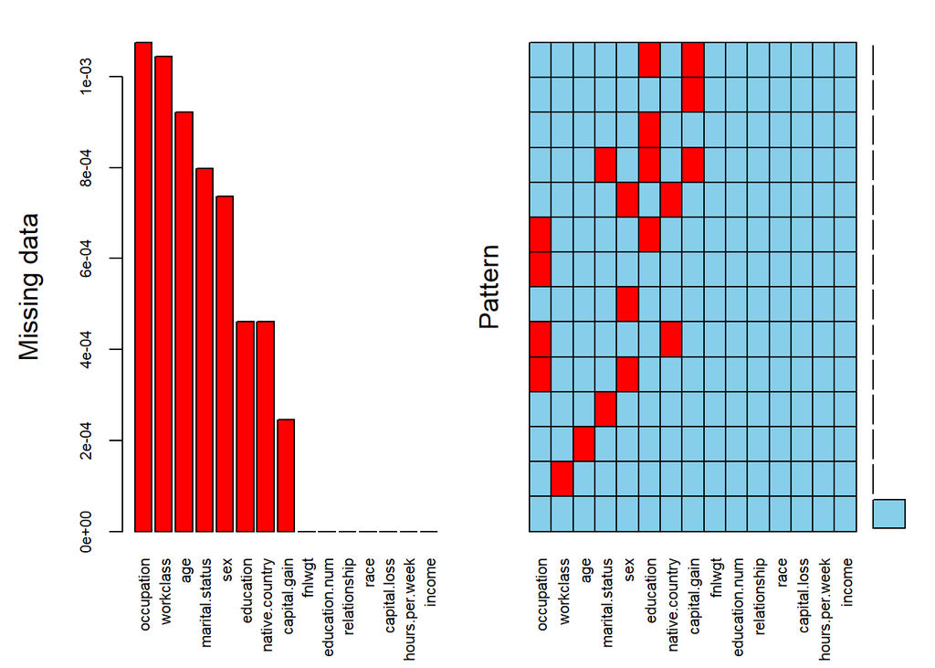

   ```
   ##
   ##  Variables sorted by number of missings:
   ##        Variable        Count
   ##      occupation 0.0010749056
   ##       workclass 0.0010441940
   ##             age 0.0009213476
   ##  marital.status 0.0007985013
   ##             sex 0.0007370781
   ##       education 0.0004606738
   ##  native.country 0.0004606738
   ##    capital.gain 0.0002456927
   ##          fnlwgt 0.0000000000
   ##   education.num 0.0000000000
   ##    relationship 0.0000000000
   ##            race 0.0000000000
   ##    capital.loss 0.0000000000
   ##  hours.per.week 0.0000000000
   ##          income 0.0000000000
   ```

   ```r
   aggr(df,
        numbers = TRUE,
        sortVars = TRUE,
        labels = names(df),
        cex.axis = 0.7,
        gap = 3,
        ylab = c("Missing data", "Pattern"))
   ```

3. Find other forms of missing values. Hint: You can use the `table` function to check if there are suspicious categories (Unknown, for example) in a variable. What all other forms of missing values shown in the data.

   ```r
   df %>%
     select(where(is.character)) %>%
     lapply(table, useNA = "ifany")
   ```

   ```
   ## $workclass
   ##
   ##                ?      Federal-gov        Local-gov     Never-worked
   ##             1835              957             2086                7
   ##        Not Known          Private     Self-emp-inc Self-emp-not-inc
   ##               12            22664             1110             2537
   ##        State-gov          Unknown      Without-pay             <NA>
   ##             1293               12               14               34
   ##
   ## $education
   ##
   ##         10th         11th         12th      1st-4th      5th-6th      7th-8th
   ##          931         1174          431          168          333          645
   ##          9th   Assoc-acdm    Assoc-voc    Bachelors    Doctorate      HS-grad
   ##          514         1064         1376         5342          413        10475
   ##      Masters    Not Known    Preschool  Prof-school Some-college      Unknown
   ##         1719           36           51          575         7273           26
   ##         <NA>
   ##           15
   ##
   ## $marital.status
   ##
   ##              Divorced     Married-AF-spouse    Married-civ-spouse
   ##                  4435                    23                 14963
   ## Married-spouse-absent         Never-married             Not Known
   ##                   418                 10666                    12
   ##             Separated               Widowed                  <NA>
   ##                  1025                   993                    26
   ##
   ## $occupation
   ##
   ##                 ?      Adm-clerical      Armed-Forces      Craft-repair
   ##              1840              3761                 9              4090
   ##   Exec-managerial   Farming-fishing Handlers-cleaners Machine-op-inspct
   ##              4059               993              1368              2001
   ##         Not Known     Other-service   Priv-house-serv    Prof-specialty
   ##                12              3287               149              4132
   ##   Protective-serv             Sales      Tech-support  Transport-moving
   ##               647              3647               924              1594
   ##           Unknown              <NA>
   ```

   [output cut: 59 more lines]

   ```
   ##                      South                     Taiwan
   ##                         80                         51
   ##                   Thailand            Trinadad&Tobago
   ##                         18                         18
   ##              United-States                    Unknown
   ##                      29110                         26
   ##                    Vietnam                 Yugoslavia
   ##                         67                         16
   ##                       <NA>
   ##                         15
   ##
   ## $income
   ##
   ## <=50K  >50K
   ## 24720  7841
   ```

4. Replace all the forms of missing values found to NA

   ```r
   df <- df %>%
     mutate(across(where(is.character),
                   ~ ifelse(. %in% c("Unknown", "Not Available", "N/A", "", "NULL", "?"),
                            NA, .)))
   ```

5. Replot the number of NAs for each column.

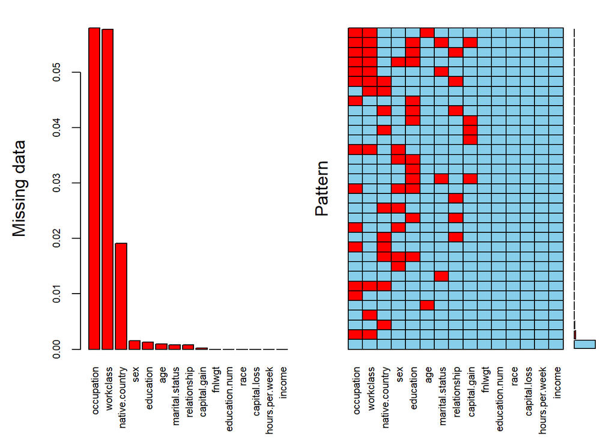

   ```
   ##
   ##  Variables sorted by number of missings:
   ##        Variable        Count
   ##      occupation 0.0579834772
   ##       workclass 0.0577684961
   ##  native.country 0.0191333190
   ##             sex 0.0015355794
   ##       education 0.0012591751
   ##             age 0.0009213476
   ##  marital.status 0.0007985013
   ##    relationship 0.0007985013
   ##    capital.gain 0.0002456927
   ##          fnlwgt 0.0000000000
   ##   education.num 0.0000000000
   ##            race 0.0000000000
   ##    capital.loss 0.0000000000
   ##  hours.per.week 0.0000000000
   ##          income 0.0000000000
   ```

   ```r
   library(VIM)

   aggr(df,
        numbers = TRUE,
        sortVars = TRUE,
        labels = names(df),
        cex.axis = 0.7,
        gap = 3,
        ylab = c("Missing data", "Pattern"))
   ```

6. Approach 1 to handle NAs: remove all rows that have any NAs. Save the dataset after removing as a different data. The original data is unchanged (still have NAs). How many rows left after removing?

   ```r
   df_drop <- df %>% tidyr::drop_na()

   nrow(df_drop)
   ```

   ```
   ## [1] 29959
   ```

7. Approach 2 to handle NAs: Fill all the NAs with the previous or next value. (Hint: Using `fill` function). Save the dataset after filling as a different data. The original data is unchanged (still have NAs).

   ```r
   library(tidyr)
   library(dplyr)

   df_fill <- df %>%
     fill(everything(), .direction = "downup")
   ```

8. Approach 3 to handle NAs: For numeric variable, replace the NAs by the median. For categorical variables, replace the NAs to the majority.

```r
library(dplyr)

mode_value <- function(x) {
  ux <- na.omit(x)
  if (length(ux) == 0) return(NA)
  names(sort(table(ux), decreasing = TRUE))[1]
}

df_impute <- df %>%
  mutate(
    across(where(is.numeric),
           ~ ifelse(is.na(.), median(., na.rm = TRUE), .)),
    across(where(~ is.character(.) || is.factor(.)),
           ~ {
             m <- mode_value(.)
             ifelse(is.na(.), m, .)
           })
  )
```